# Modern Research & Data Science

Philosophy, Paradigms, and AI-Augmented Reproducibility

Workshop Introduction

9–10 September 2026

## Workshop Overview

Modern research lies at the intersection of classical philosophy, rigorous statistical frameworks, and cutting-edge artificial intelligence. This workshop bridges these domains to build quality-conscious, reproducible workflows.

**Part I: Philosophy of Knowledge**  
From ontology and epistemology to logical inference (induction, deduction, reduction).

**Part II: Data Analysis Paradigms**  
Frequentist, Bayesian, and Artificial Intelligence paradigms.

**Part III: Domain Focus**  
Methodological applications in Clinical/Pharmaceutical Research and Econometrics.

**Part IV: The Modern AI-Augmented Stack**  
Literate programming in R & Quarto, accelerated by Generative AI.

# Part I — Research Philosophy

### From Ontology to Epistemology, and the Structures of Inquiry

## Ontology & Epistemology

Philosophical foundations

Every study design choice is a downstream consequence of a philosophical position.

### Ontology: What is reality?

- **Realism / Objectivism:** There is a single, objective reality independent of our perception.
- **Relativism / Subjectivism:** Reality is constructed socially, meaning multiple truths exist.

### Epistemology: How do we know it?

- **Empiricism:** Knowledge is derived from sensory, observational evidence.
- **Rationalism:** Knowledge is derived from logical reasoning and intellect.

In clinical and quantitative econometrics, we search for objective, reproducible truths (realist ontology, empirical epistemology).

## Positivism vs. Constructivism

Research Traditions

How do these ontological and epistemological choices shape our research traditions?

| Feature | Positivist Tradition | Constructivist Tradition |
| --- | --- | --- |
| **Ontological Stance** | Single, objective, discoverable reality. | Multiple, constructed, contextual realities. |
| **Goal of Inquiry** | Formulate general laws, establish causal links. | Understand subjective meanings and experiences. |
| **Role of Researcher** | Detached, objective observer. | Engaged, co-creator of meaning. |
| **Typical Data** | Quantitative, structured measurements. | Qualitative, unstructured interviews or text. |

## Logical Inference: Induction to Deduction

Generating and Testing Knowledge

Science moves in cycles between building theories and testing them.

### Induction: Theory-Building

- Starts with **observations**.
- Detects patterns and regularities.
- Formulates tentative hypotheses.
- Generates general theories.

$$\text{Observations} \rightarrow \text{Pattern} \rightarrow \text{Theory}$$

### Deduction: Theory-Testing

- Starts with a **theory**.
- Derives testable hypotheses.
- Collects observations.
- Confirms or rejects the hypothesis.

$$\text{Theory} \rightarrow \text{Hypothesis} \rightarrow \text{Validation}$$

## Reductionism & Systems Thinking

How We Analyze Systems

Scientific inquiry has historically relied on breaking systems down, but modern science requires integration.

### Reductionism

- The belief that complex phenomena can be entirely explained by analyzing their simplest physical components.
- *Example:* Explaining human disease solely at the level of cellular biology or molecular genetics.

“Divide each difficulty into as many parts as is feasible.” — René Descartes

### Systems Thinking

- The belief that the whole is greater than the sum of its parts.
- *Example:* Recognizing that health outcomes are shaped by a complex web of biological, social, and economic factors.
- Essential for understanding emergent properties in pharmacology and econometrics.

# Part II — Three Paradigms of Data Analysis

### Frequentist, Bayesian, and Artificial Intelligence

## 1. The Frequentist Paradigm

Paradigms of Data Analysis

The historical bedrock of clinical trials and classical econometrics.

- **Definition of Probability:** The limit of relative frequencies in an infinite number of identical, hypothetical trials.
- **Core Characteristic:** Parameters of interest ($\theta$) are considered *fixed, unknown constants*. Data ($D$) are *random variables*.
- **Key Tools:** Null Hypothesis Significance Testing (NHST), $p$-values, confidence intervals.

$$\text{Hypothesis: } H_0: \theta = 0 \quad \text{vs.} \quad H_1: \theta \neq 0$$

A $p$-value represents $P(D \mid H_0)$ — the probability of observing data at least as extreme as ours, *assuming* the null hypothesis is true. It is **not** the probability that the hypothesis is true.

## 2. The Bayesian Paradigm

Paradigms of Data Analysis

A coherent framework for updating beliefs as new evidence accumulates.

- **Definition of Probability:** A measure of belief or certainty, conditional on current information.
- **Core Characteristic:** Parameters ($\theta$) are *random variables* with probability distributions. Data ($D$) are *fixed, observed constants*.
- **Key Tool:** Bayes’ Theorem.

$$P(\theta \mid D) = \frac{P(D \mid \theta) P(\theta)}{P(D)}$$

- $P(\theta \mid D)$: **Posterior** (belief after seeing data)
- $P(D \mid \theta)$: **Likelihood** (data explanation)
- $P(\theta)$: **Prior** (belief before seeing data)
- $P(D)$: **Marginal Likelihood** (normalizing constant)

## 3. The Artificial Intelligence Paradigm

Paradigms of Data Analysis

A shift from explaining parameters to predicting outcomes using high-dimensional data.

- **Core Focus:** Generalization and predictive accuracy ($y \approx \hat{f}(X)$) rather than isolating specific, low-dimensional parameter estimates ($\beta$).
- **Mechanism:** Algorithmic pattern recognition. The model architecture learns representations from vast, complex datasets without requiring rigid, pre-specified functional forms.
- **Generative AI:** Learning the underlying probability distribution of data ($P(X)$ or $P(X \mid Y)$) to generate new, realistic samples (e.g., text, molecules, synthetic patient cohorts).

**The Trade-off:** While frequentist and Bayesian models favor interpretability and causality, the AI paradigm favors raw predictive capacity and handling high-dimensional complexity.

## Comparing the Three Paradigms

Synthesis

| Dimension | Frequentist | Bayesian | Artificial Intelligence |
| --- | --- | --- | --- |
| **Goal** | Isolate effects; test hypotheses | Update belief distributions | Maximize predictive accuracy |
| **Parameter Status** | Fixed, unknown constant | Random variable | Implicitly learned representations |
| **Key Output** | Point estimates, $p$-values, CIs | Posterior distributions, Credible intervals | Predictions, generated text/data |
| **Assumptions** | Strong distributional assumptions | Requires specifying a prior | Weak structural assumptions |
| **Best Used For** | Regulatory clinical trials | Sequential decision-making | High-dimensional prediction |

# Part III — Domain-Specific Applications

### Clinical, Pharmaceutical, and Econometric Research

## Clinical & Pharmaceutical Research

Domain Focus

In healthcare and drug development, reproducibility and safety are paramount.

### Methodological Needs

- **Gold Standard:** Randomized Controlled Trials (RCTs) to eliminate selection bias.
- **Safety & Efficacy:** Survival Analysis (Cox Proportional Hazards), pharmacokinetic (PK/PD) modeling.
- **Regulatory Rigor:** Standardized protocols, pre-registration of trials, strict statistical bounds.

### Role of Generative AI

- **Synthetic Control Arms:** Modeling placebo groups based on historical trial data to reduce trial costs.
- **Drug Discovery:** Using generative chemistry (diffusion models) to design novel molecules targeting specific receptors.
- **Drafting Protocols:** Generating drafts of regulatory filings, consent forms, and ethics applications.

## Econometric Analysis

Domain Focus

Econometrics focuses on identifying causal relationships from observational data where experiments are impossible.

### Methodological Needs

- **Causal Inference:** Techniques to bypass confounding and establish causality:
  - **Difference-in-Differences (DiD)**
  - **Instrumental Variables (IV)**
  - **Regression Discontinuity (RDD)**
  - **Propensity Score Matching**
- **Policy Evaluation:** Isolating the net impact of macro policies or social interventions.

### Role of Generative AI

- **Synthetic Controls:** Automating the creation of synthetic control groups using predictive modeling.
- **Unstructured Data Extraction:** Parsing millions of policy documents, financial filings, or news transcripts into structured variables for econometric models.
- **Advanced Controls:** Integrating machine learning (Double/Debiased Machine Learning) to isolate causal effects in high-dimensional settings.

# Part IV — Quality, Reproducibility, & Generative AI

### Elevating Research Quality in the Era of AI

## The Reproducibility Crisis

Quality-Conscious Research

Too many published findings cannot be replicated by independent researchers.

### Common Pitfalls

- **$p$-Hacking:** Searching through multiple variables or sub-groups until a statistically significant result emerges.
- **HARKing:** Hypothesizing After Results are Known.
- **Data Dredging:** Running regression after regression without a pre-registered analysis plan.
- **Manual Errors:** Copypasting numbers from statistical software into word documents.

### The Modern Data Science Solution

- **Literate Programming:** Combining code, math, outputs, and text in a single document (Quarto).
- **Version Control:** Tracking code history and collaboration with Git.
- **Environment Management:** Recording package versions (e.g., `renv`) to ensure code runs the same way on any machine, today or in ten years.

## Quarto: The Reproducible Pipeline

Quality-Conscious Research

Quarto is a multi-language, next-generation version of R Markdown.

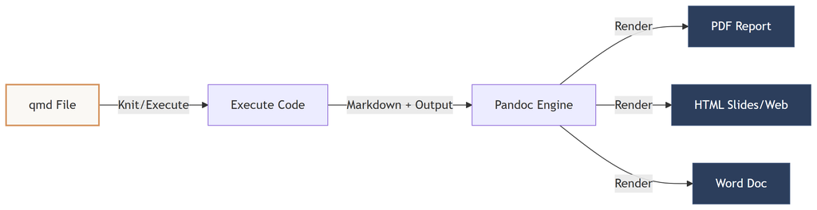

- **No Copy-Pasting:** If the data changes, simply re-run the file; tables, figures, and inline values update automatically.
- **Interoperability:** Write in R, Python, Julia, or SQL inside the same document.

## Leveraging Generative AI Responsibly

Generative AI in Research

Generative AI is a powerful assistant, not a replacement for domain expertise.

### What GenAI Does Exceptionally Well

- **Accelerating Code:** Writing boilerplate R, RStudio functions, or complex ggplot visualisations.
- **Literature Syntheses:** Drafting initial summaries of complex papers (always check the source).
- **Document Formatting:** Formatting raw text into markdown tables or slide structures.
- **Debugging:** Explaining error logs and suggesting corrections.

### The Critical Risks

- **Hallucinations:** Inventing citations, data points, or R functions that do not exist.
- **Logical Gaps:** Generating code that runs but calculates the wrong statistical metric.
- **Compliance Issues:** Uploading sensitive, non-anonymized patient data to external servers.

## The AI-Augmented Workflow

The Way Forward

Quality-conscious researchers use Generative AI as an iterative partner under strict human control.

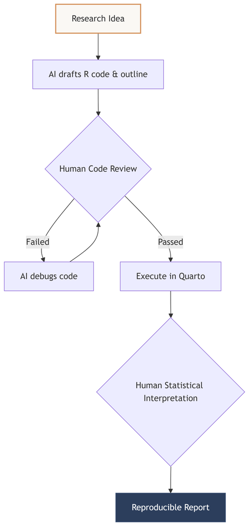

- **Rule of Thumb:** Never publish a line of code or a citation you have not personally verified.
- **Goal:** Use AI to handle the cognitive friction of syntax, freeing your mind to focus on study design, methodology, and interpretation.